# Publication bias in experimental philosophy: analysis report

# Prescreening

## [P1] Have you completed a doctoral degree (or equivalent terminal degree, e.g., PhD, EdD, JD, MFA, MBA)?

| P1 | n | % |
| --- | --- | --- |
| No | 4 | 8.00 |
| Yes | 46 | 92.00 |

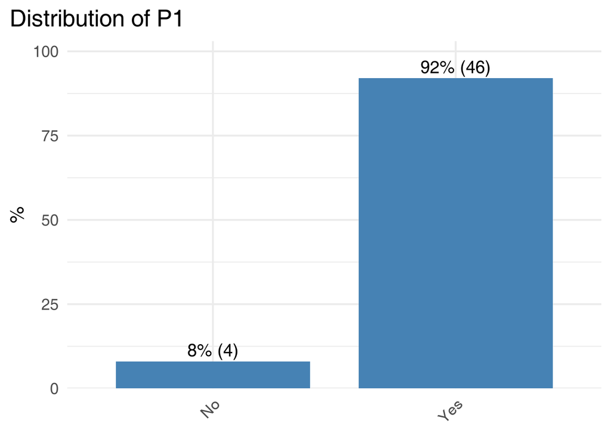

## [P2] Are you currently pursuing a PhD in philosophy or a related field (e.g., cognitive science, psychology)?

| P2 | n | % |
| --- | --- | --- |
| Yes | 4 | 8.00 |
|  | 46 | 92.00 |

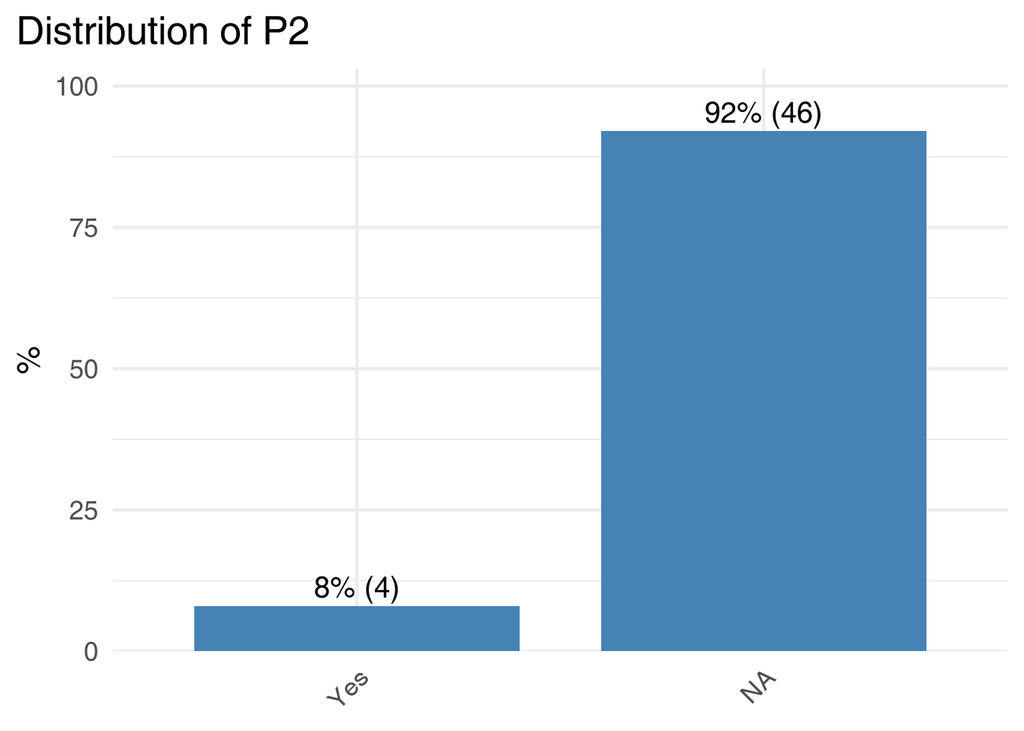

## [P3] Do you conduct quantitative experimental or empirical research in experimental philosophy or related to experimental philosophy? (Note: By quantitative research, we mean research with data collection that results in numerical data)

| P3 | n | % |
| --- | --- | --- |
| Yes | 50 | 100.00 |

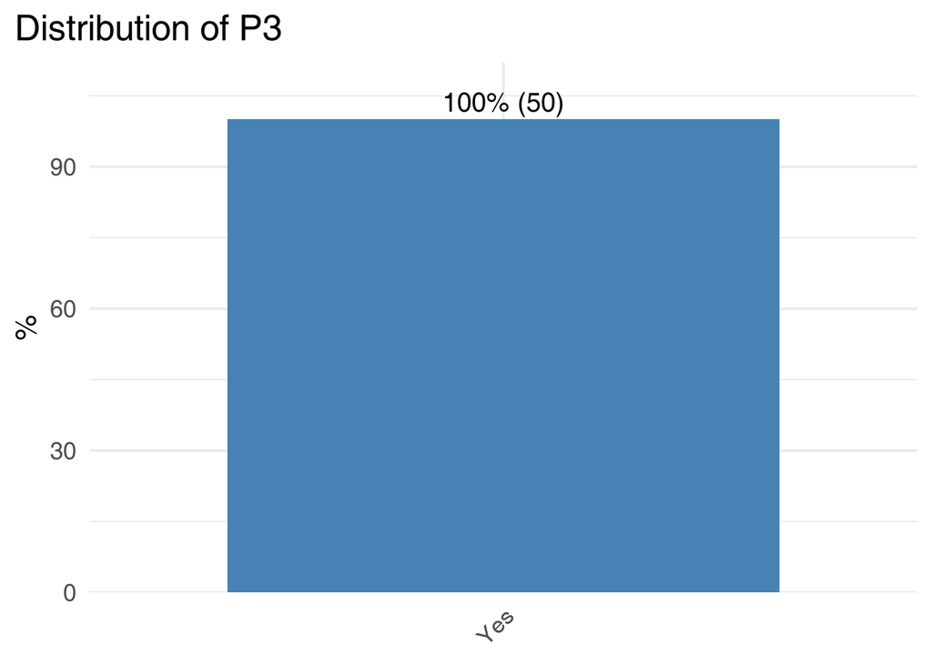

## [P4] Are you currently affiliated with a university/research institution (e.g., as a student, faculty member, or researcher)?

| P4 | n | % |
| --- | --- | --- |
| Yes | 50 | 100.00 |

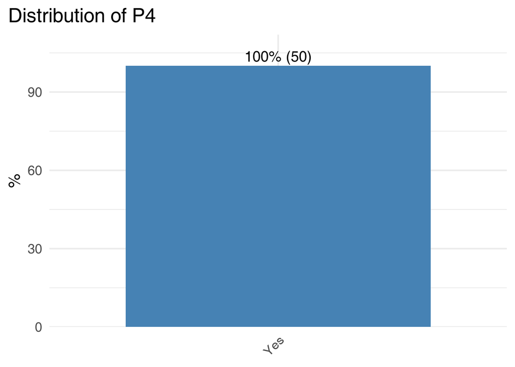

# Demography

## [D1] In which year did you complete your first doctoral (or equivalent terminal) degree (e.g., PhD, EdD, JD, MFA, MBA)?

| n | M | SD |
| --- | --- | --- |
| 46 | 2,016.72 | 7.34 |

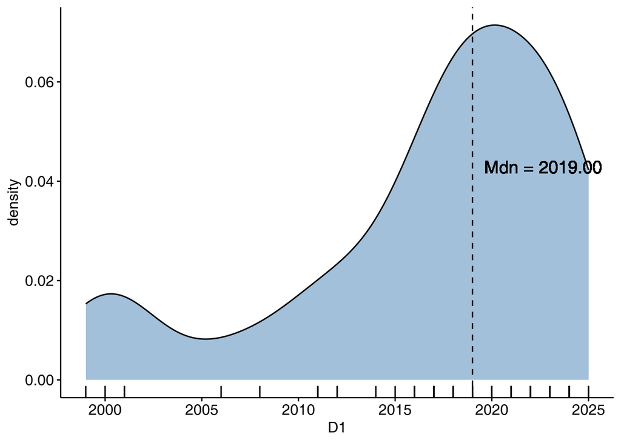

## [D2] In which year did you begin your first doctoral (or equivalent terminal) degree program?

| n | M | SD |
| --- | --- | --- |
| 50 | 2,012.22 | 7.97 |

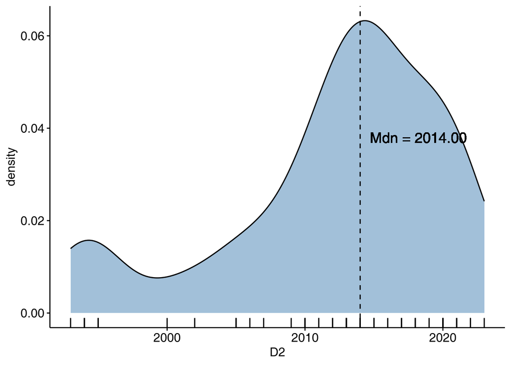

## [D3] How many years have you been actively conducting research in experimental philosophy?

| n | M | SD |
| --- | --- | --- |
| 50 | 9.14 | 5.27 |

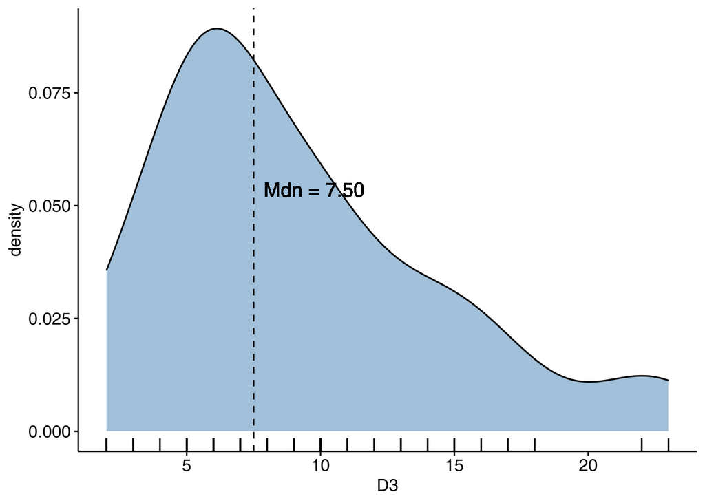

## [D4] In which country did you complete your doctoral (or equivalent terminal) degree?

| D4 | n | % |
| --- | --- | --- |
| Australia | 1 | 2.00 |
| Austria | 1 | 2.00 |
| Belgium | 2 | 4.00 |
| Brazil | 1 | 2.00 |
| China | 1 | 2.00 |
| Finland | 1 | 2.00 |
| France | 1 | 2.00 |
| Germany | 5 | 10.00 |
| Japan | 1 | 2.00 |
| Lithuania | 1 | 2.00 |
| Netherlands | 1 | 2.00 |
| Poland | 10 | 20.00 |
| Romania | 1 | 2.00 |
| Spain | 1 | 2.00 |
| Switzerland | 2 | 4.00 |
| United States of America | 10 | 20.00 |
| the United Kingdom of Great Britain and Northern Ireland | 6 | 12.00 |
|  | 4 | 8.00 |

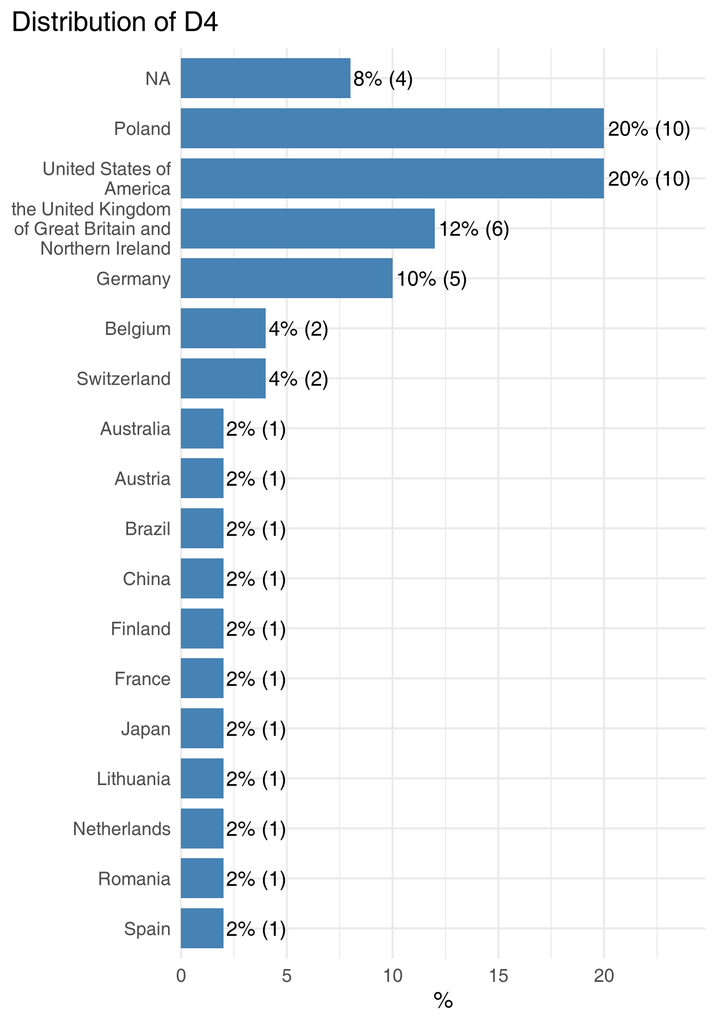

## [D5] During your undergraduate or graduate studies (e.g., MA, PhD), how many courses or training sessions did you complete that focused primarily on quantitative research methods and/or statistics?

| n | M | SD |
| --- | --- | --- |
| 50 | 2.90 | 3.52 |

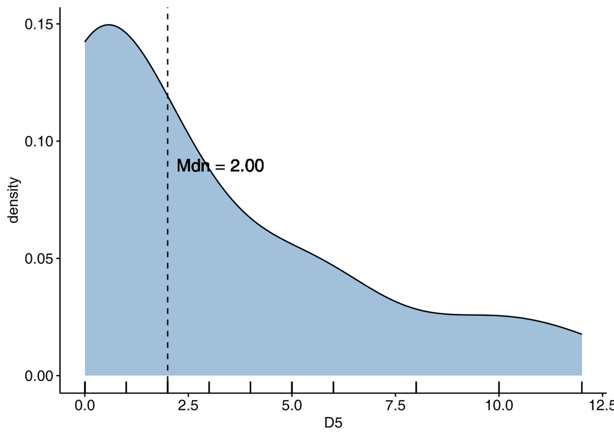

## [D6] In which country is your current university/institution located?

| D6 | n | % |
| --- | --- | --- |
| Australia | 1 | 2.00 |
| Austria | 1 | 2.00 |
| Belgium | 3 | 6.00 |
| Brazil | 1 | 2.00 |
| Denmark | 1 | 2.00 |
| Estonia | 1 | 2.00 |
| Germany | 7 | 14.00 |
| Japan | 1 | 2.00 |
| Lithuania | 1 | 2.00 |
| Netherlands | 1 | 2.00 |
| New Zealand | 2 | 4.00 |
| Norway | 2 | 4.00 |
| Poland | 9 | 18.00 |
| Romania | 1 | 2.00 |
| Spain | 2 | 4.00 |
| Switzerland | 5 | 10.00 |
| United States of America | 8 | 16.00 |
| the United Kingdom of Great Britain and Northern Ireland | 3 | 6.00 |

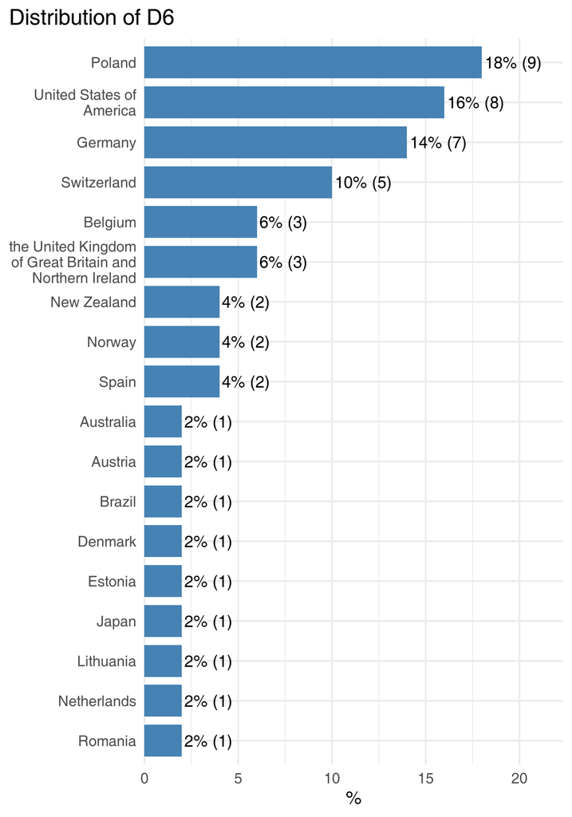

## [D7] What is your current professional title or role?

| D7 | n | % |
| --- | --- | --- |
| Assistant Professor (or equivalent) | 14 | 28.00 |
| Associate Professor (or equivalent) | 6 | 12.00 |
| Full Professor (or equivalent) | 8 | 16.00 |
| Graduate Student | 4 | 8.00 |
| Other | 1 | 2.00 |
| Post-Doctoral Fellow | 17 | 34.00 |

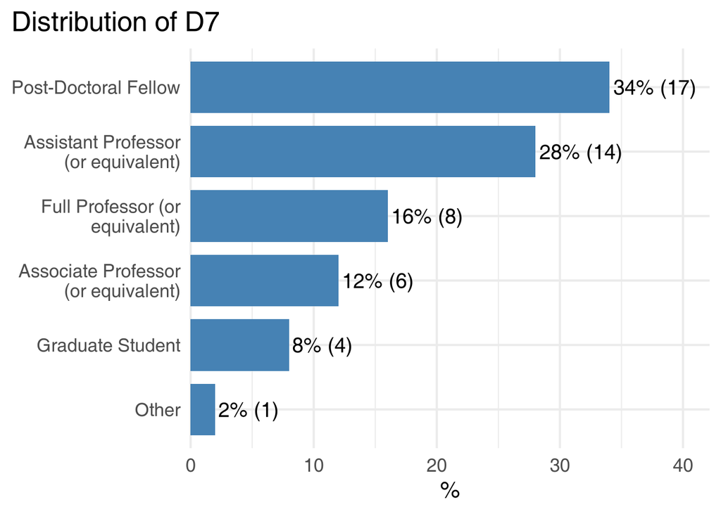

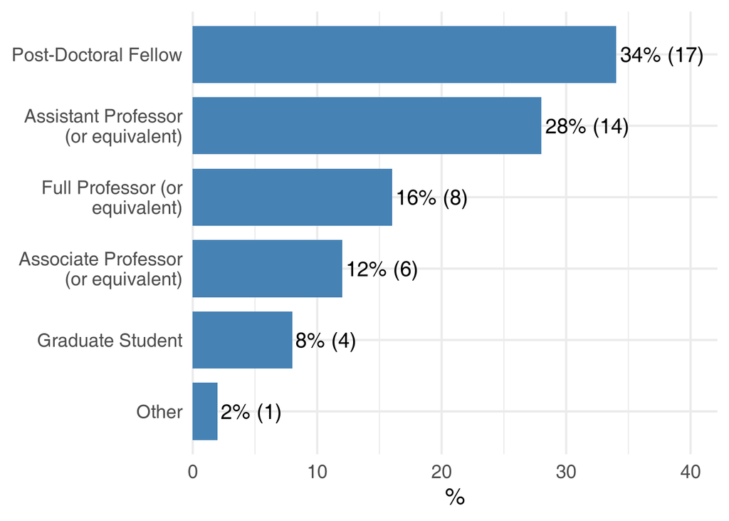

## [D8] Which of the following disciplines most closely aligns with your primary research area in experimental philosophy?

| Option | n | % |
| --- | --- | --- |
| philosophy of language | 25 | 50.00 |
| ethics | 22 | 44.00 |
| philosophy of mind | 17 | 34.00 |
| epistemology | 13 | 26.00 |
| philosophy of action | 9 | 18.00 |
| metaphysics | 9 | 18.00 |
| foundations of experimental philosophy | 8 | 16.00 |
| philosophy of law | 8 | 16.00 |
| Other (free text) | 6 | 12.00 |
| logic and argumentation theory | 5 | 10.00 |
| aesthetics and philosophy of art | 3 | 6.00 |
| philosophy of religion | 1 | 2.00 |

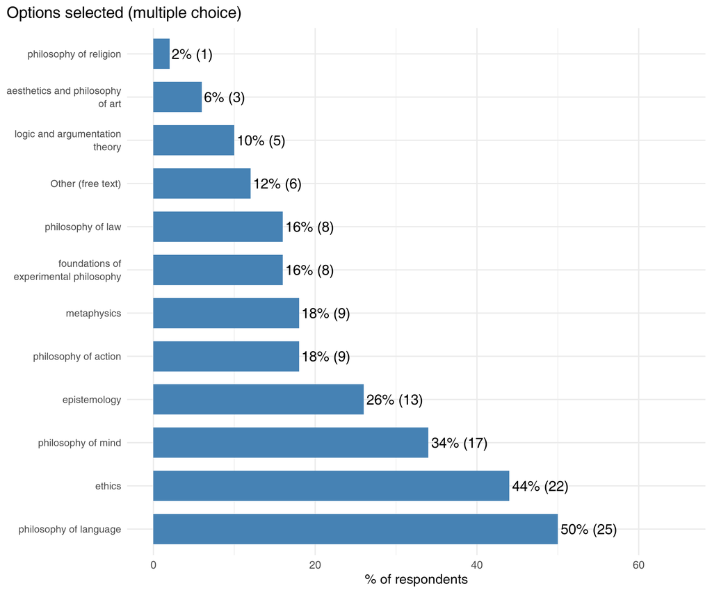

| Question | response |
| --- | --- |
| Other | philosophy of science |
| Other | Moral psychology |
| Other | philosophy of maths |
| Other | philosophy of mathematics |
| Other | philosophy of science |
| Other | cognitive science |

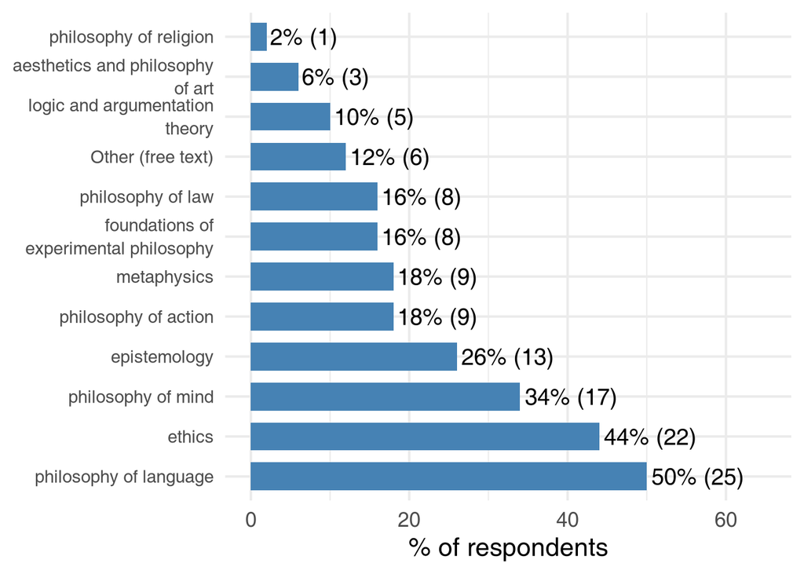

## For the following questions, consider your publication activity over the past 5 years and provide an average estimate. Note: If you began your doctoral (or equivalent terminal) degree fewer than 5 years ago, base your responses only on the period since you started that degree.

## [D9] On average, how many experimental philosophy projects (e.g., research articles, book chapters) do you publish per year? Please consider both theoretical and empirical research, including single- and co-authored projects.

| n | M | SD |
| --- | --- | --- |
| 50 | 1.95 | 1.76 |

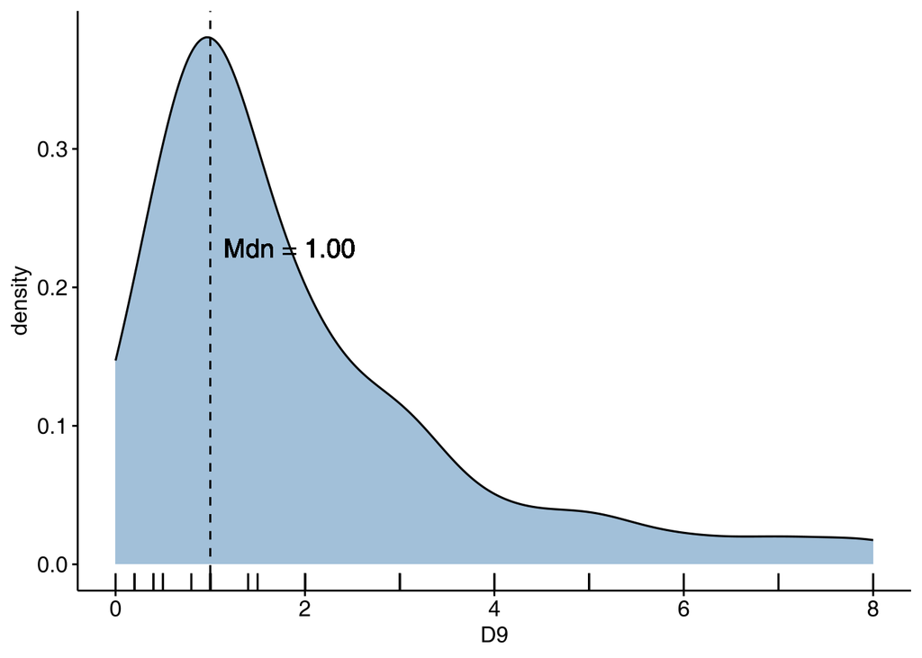

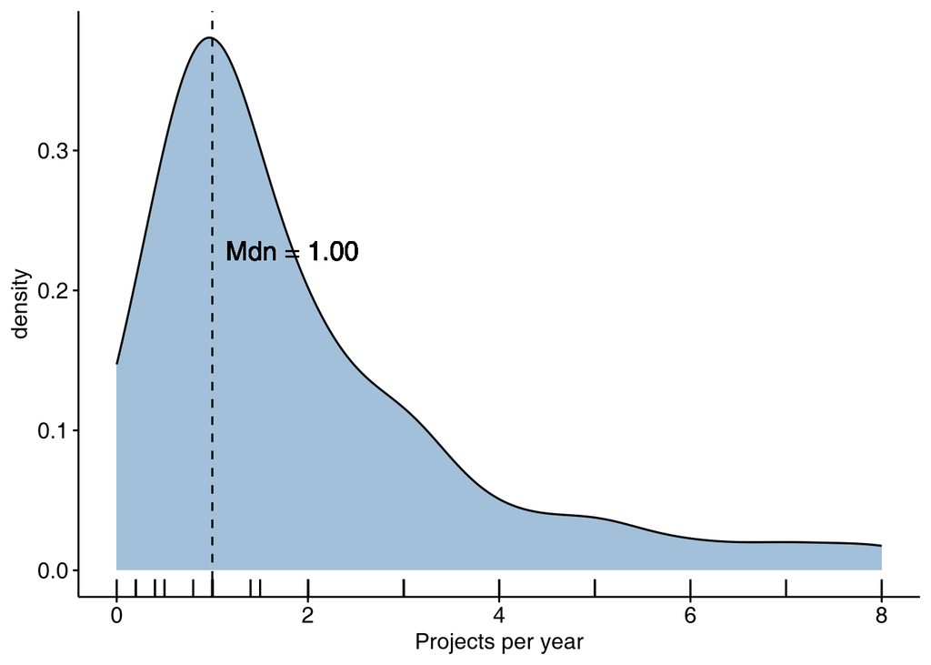

## [D10] How many of your experimental philosophy projects published per year appear in peer-reviewed journals?

| n | M | SD |
| --- | --- | --- |
| 50 | 1.80 | 1.62 |

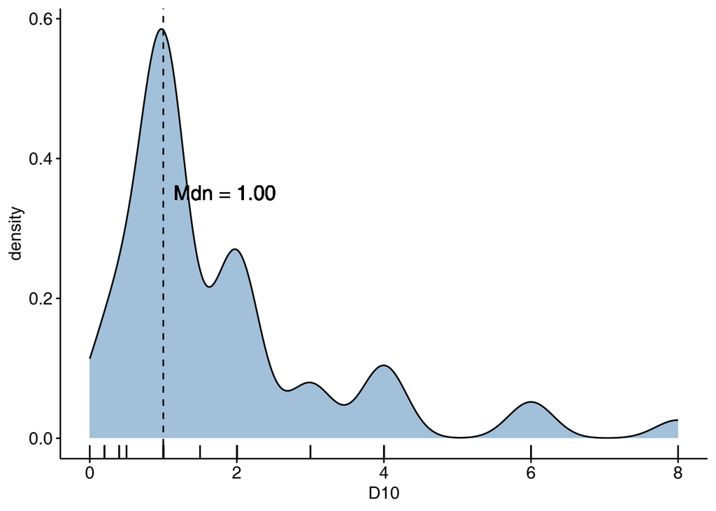

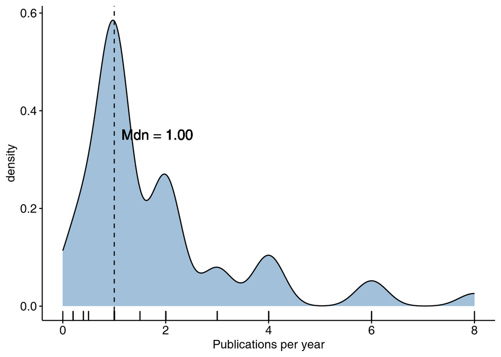

## [D11] How many of your experimental philosophy projects published each year include quantitative data analysis?

| n | M | SD |
| --- | --- | --- |
| 50 | 1.83 | 1.72 |

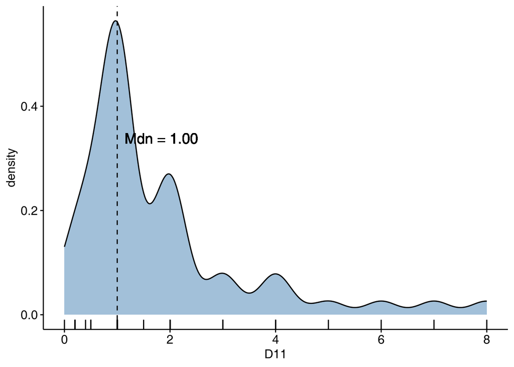

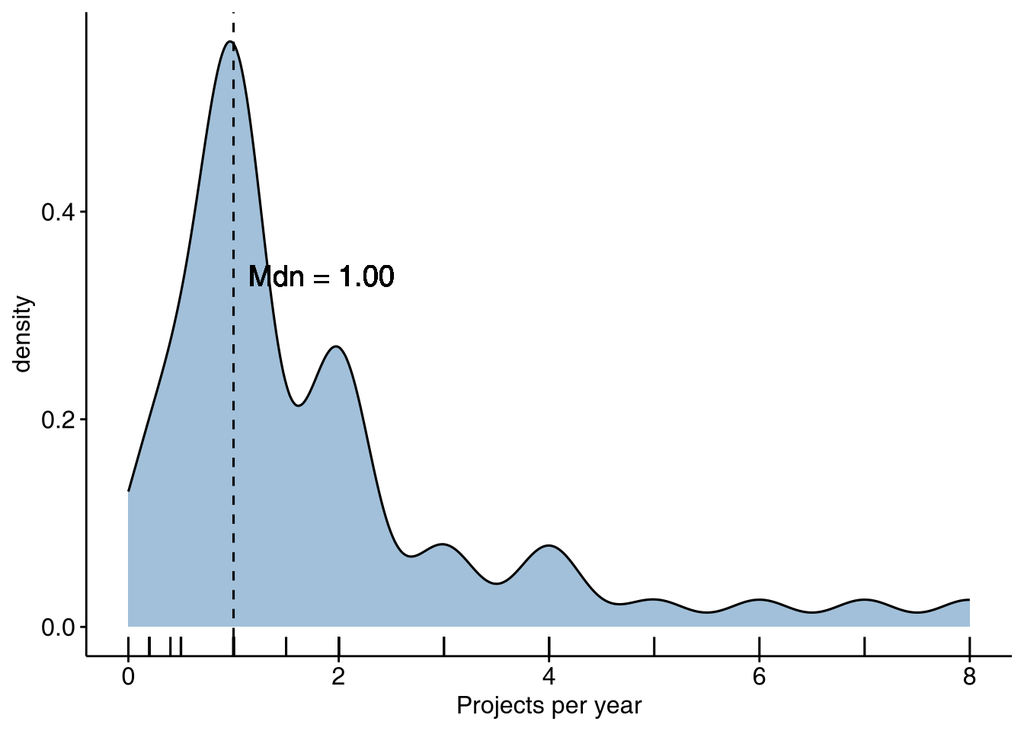

## [D12] If you have any additional comments or wish to clarify any responses, please enter them below.

This open-ended free-text item (`D12`) is **not included in the public dataset** to reduce re-identification risk.

# Prevalence

## [R1] In the past 5 years, how many of the research projects involving quantitative data analysis you have been involved in (including your students’ work) has stopped or terminated at each of the following stages?

| Scale | n | M | SD | SE |
| --- | --- | --- | --- | --- |
| Published paper | 50 | 6.98 | 9.66 | 1.37 |
| Data analysis | 50 | 1.66 | 3.10 | 0.44 |
| Professional Presentation (e.g., conference presentation, talk) | 50 | 0.98 | 1.79 | 0.25 |
| Formal Presentation (e.g., unpublished report, thesis) | 50 | 0.88 | 1.53 | 0.22 |
| Reviewed Manuscript (Reviewer's Rejection Reasons) | 50 | 0.38 | 0.78 | 0.11 |
| Submitted Manuscript (Editor's Rejection Reasons) | 50 | 0.26 | 0.78 | 0.11 |

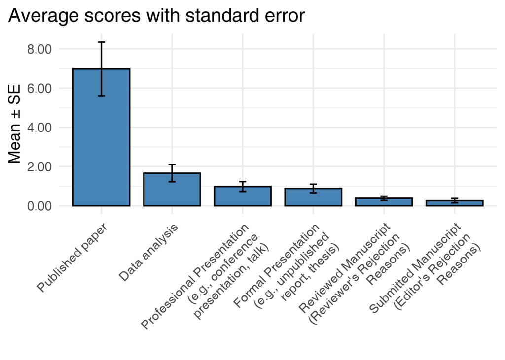

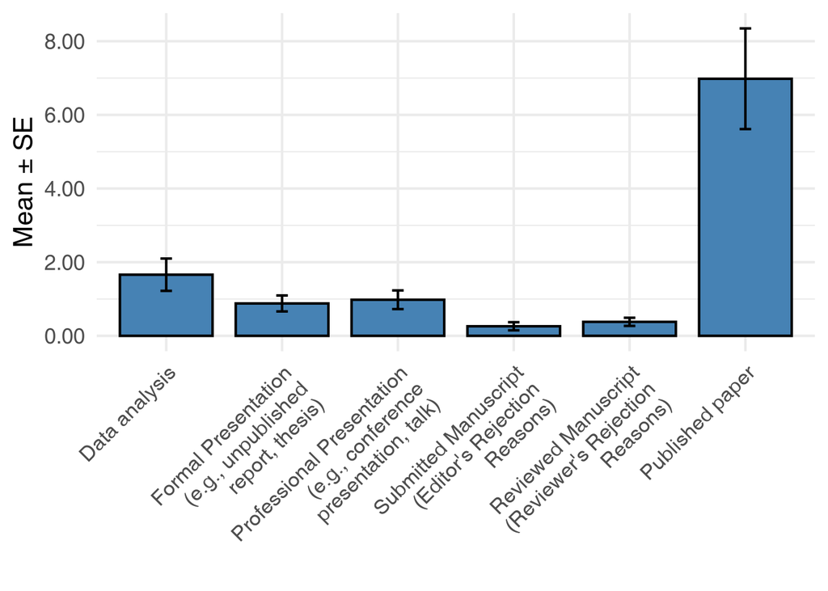

## [R2] In case of research projects that have stopped or terminated at the stage of **data analysis**, what were the reasons for termination?

| Option | n | % |
| --- | --- | --- |
| Loss of interest or lack of resources | 14 | 28.00 |
| Conceptual, methodological, or statistical concerns | 14 | 28.00 |
| Additional studies needed (follow-ups, replications, etc.) | 11 | 22.00 |
| Unimportant or unanticipated results | 10 | 20.00 |
| Null results (non-significant findings) | 8 | 16.00 |

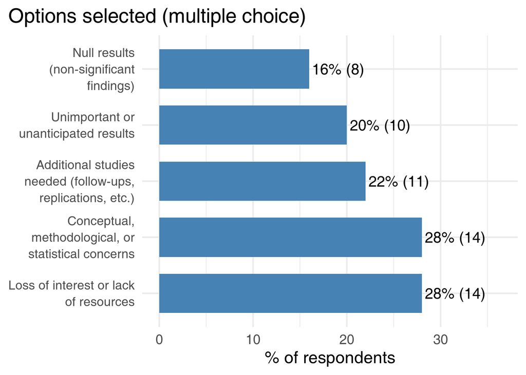

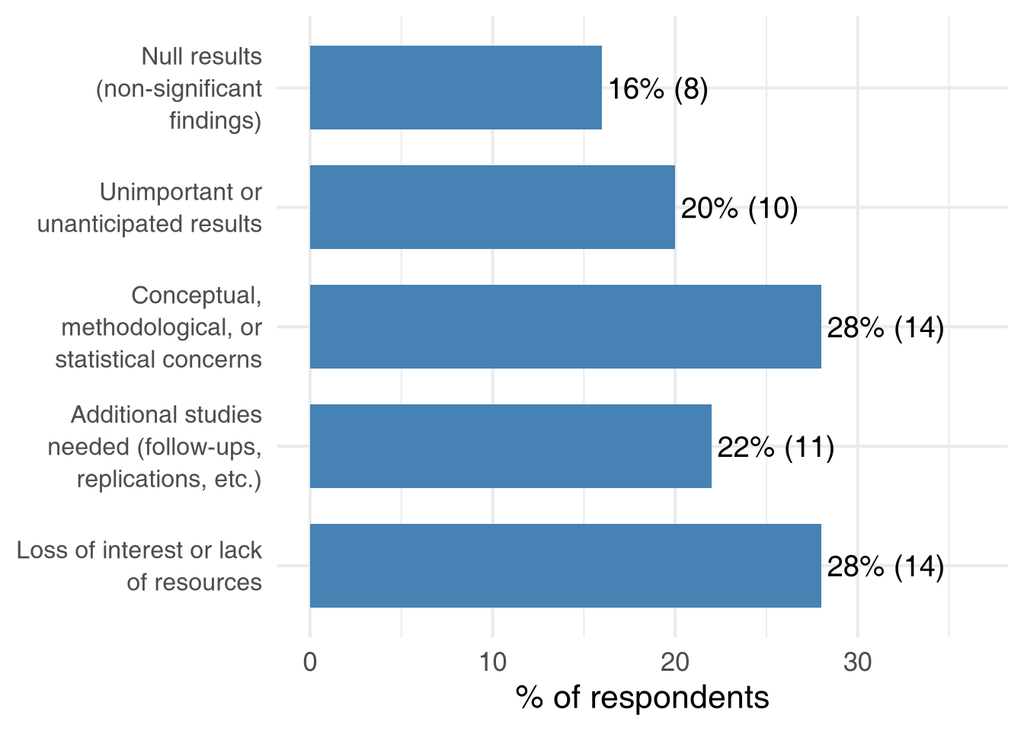

## [R3] In case of research projects that have stopped or terminated at the stage of **formal presentation**, what were the reasons for termination?

| Option | n | % |
| --- | --- | --- |
| Loss of interest or lack of resources | 14 | 28.00 |
| Additional studies needed (follow-ups, replications, etc.) | 9 | 18.00 |
| Unimportant or unanticipated results | 6 | 12.00 |
| Conceptual, methodological, or statistical concerns | 4 | 8.00 |
| Null results (non-significant findings) | 3 | 6.00 |

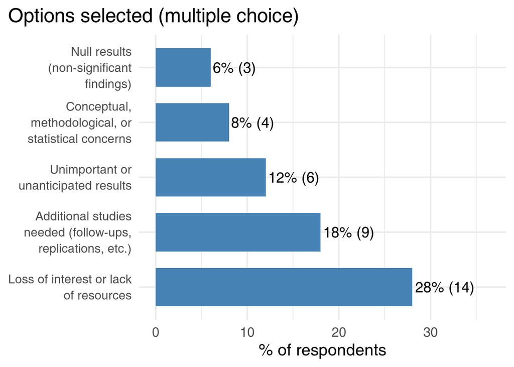

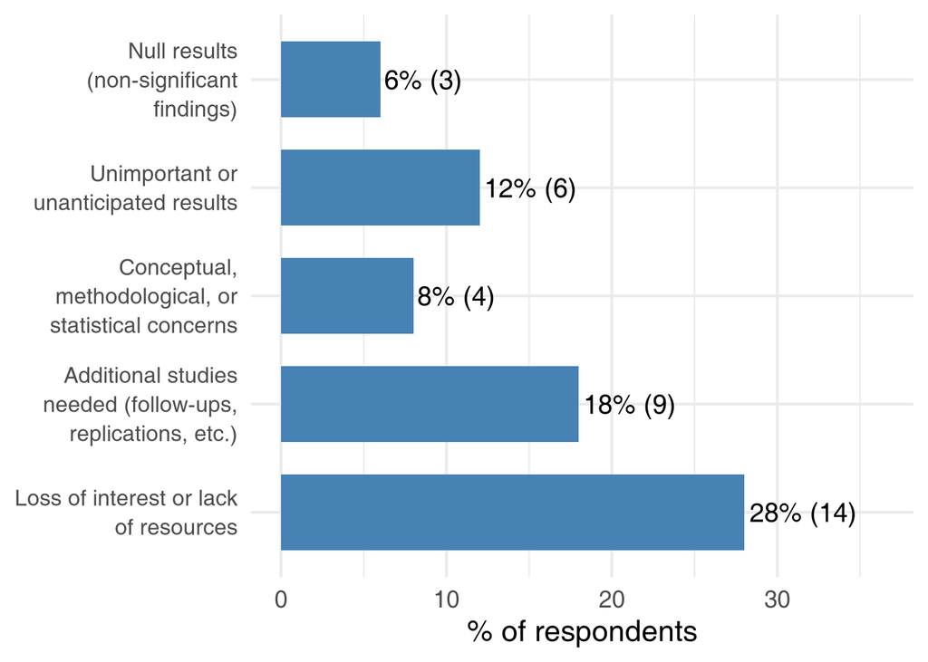

## [R4] In case of research projects that have stopped or terminated at the stage of **professional presentation**, what were the reasons for termination?

| Option | n | % |
| --- | --- | --- |
| Additional studies needed (follow-ups, replications, etc.) | 13 | 26.00 |
| Loss of interest or lack of resources | 11 | 22.00 |
| Conceptual, methodological, or statistical concerns | 7 | 14.00 |
| Unimportant or unanticipated results | 7 | 14.00 |
| Null results (non-significant findings) | 3 | 6.00 |

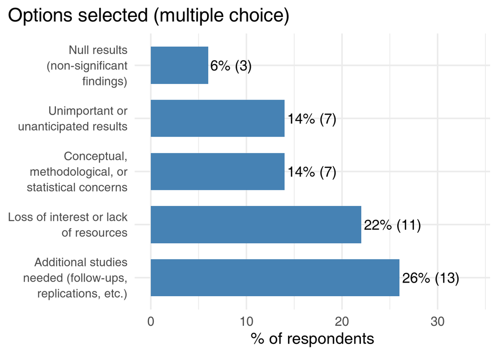

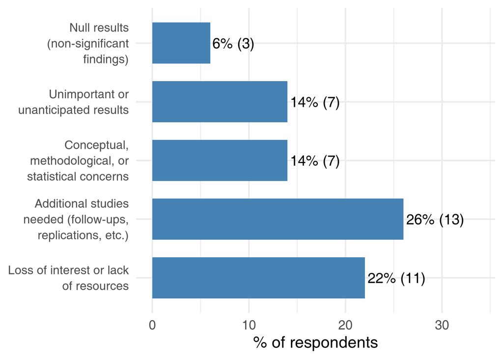

## [R5] In case of research projects that have stopped or terminated at the stage of **submitted manuscript**, what were the reasons for termination?

| Option | n | % |
| --- | --- | --- |
| Not aligned with the journal's scope or profile | 5 | 10.00 |
| Results considered unimportant by the editor | 3 | 6.00 |
| Manuscript quality concerns (e.g., poor writing, excessive length) | 3 | 6.00 |
| Null results (non-significant findings) | 0 | 0.00 |

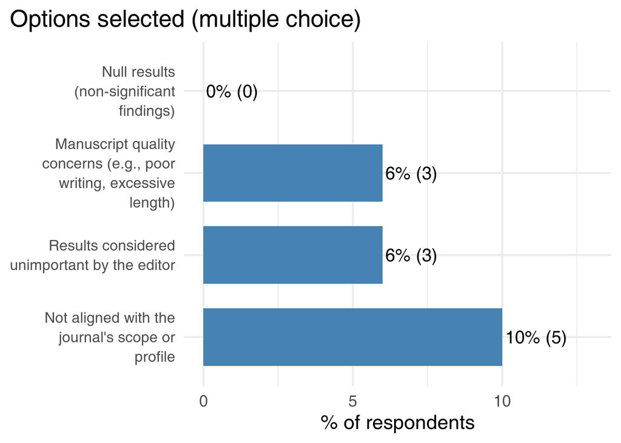

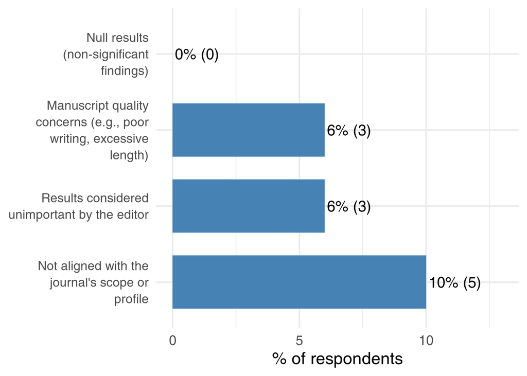

## [R6] In case of research projects that have stopped or terminated at the stage of **reviewed manuscript**, what were the reasons for termination?

| Option | n | % |
| --- | --- | --- |
| Conceptual, methodological, or statistical concerns | 8 | 16.00 |
| Results considered unimportant by reviewers | 6 | 12.00 |
| Manuscript quality concerns (e.g., poor writing, excessive length) | 4 | 8.00 |
| Null results (non-significant findings) | 0 | 0.00 |

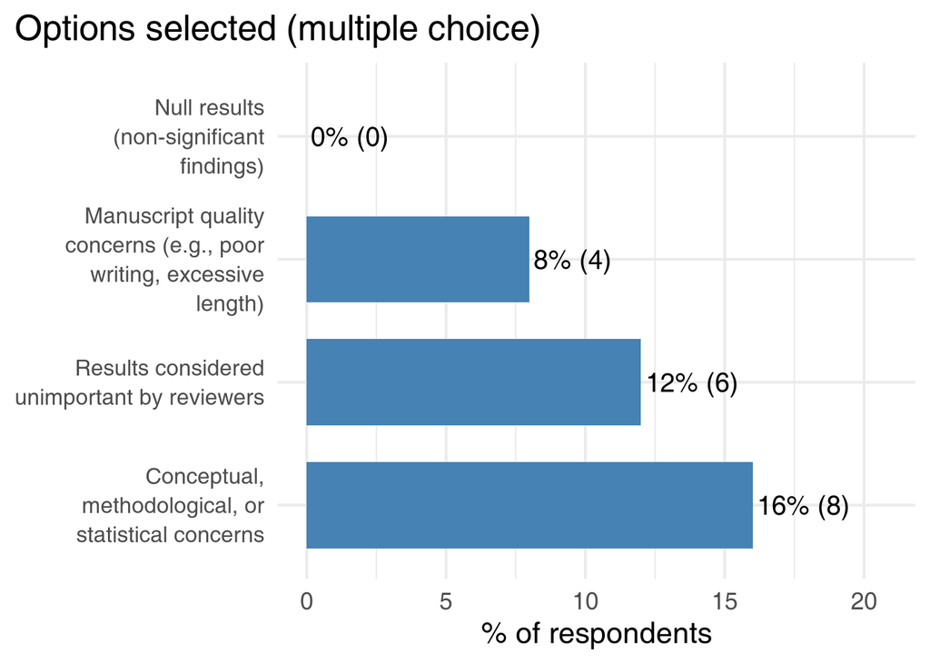

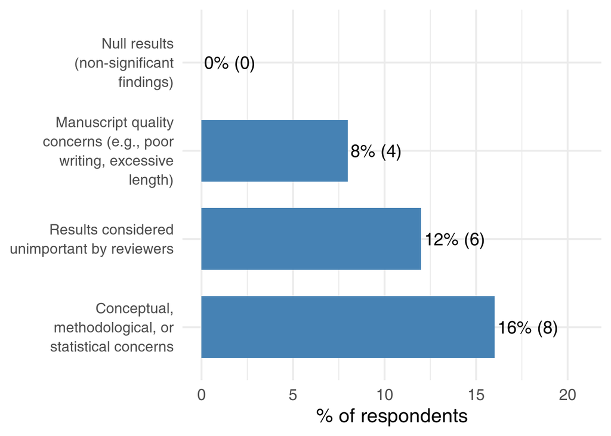